# Simulation Project

Ren Bettendorf, renb2

6/12/2019

## Simulation Study 1: Significance of Regression

### **Introduction**

In this Simulation Study we are given two models to investigate the significance of regression which we will name “**Significant**” and “**Non-Significant**”.

- **Significant Model**
  - $Y_i = \beta_0 + \beta_1 x_{i1} + \beta_2 x_{i2} + \beta_3 x_{i3} + \epsilon_i$
  - $\beta_0 = 3$
  - $\beta_1 = 1$
  - $\beta_2 = 1$
  - $\beta_3 = 1$
  - $\epsilon_i \sim N(0, \sigma^2)$
- **Non-Significant Model**
  - $Y_i = \beta_0 + \beta_1 x_{i1} + \beta_2 x_{i2} + \beta_3 x_{i3} + \epsilon_i$
  - $\beta_0 = 3$
  - $\beta_1 = 0$
  - $\beta_2 = 0$
  - $\beta_3 = 0$
  - $\epsilon_i \sim N(0, \sigma^2)$

What we mean by investigate the significance of regression is to investigate the given predictors $x_1, x_2, x_3$ and to determine if there is a linear relationship when considering these variables with $Y$. In order to show if this relationship exists though we will be doing $2,500$ simulations based upon data contained in `study_1.csv` with a sample size of $25$ with the following $\sigma \in (1, 5, 10)$ which leads to a total of $15,000$ simulations for our $Y$ variable. For comparison at the end we will consider the $F statistic$, $p-value$, and $R^2$ to determine which empirical distribution.

### **Methods**

Setup our variables to simulate our values

```r
birthday = 19890927
set.seed(birthday)
library(readr)
study_1_data = read_csv("study_1.csv")
n = 25
p = 3 + 1
x0 = rep(1, n)
x1 = study_1_data$x1
x2 = study_1_data$x2
x3 = study_1_data$x3

# Significant Model beta values
sig_beta_0 = 3
sig_beta_1 = 1
sig_beta_2 = 1
sig_beta_3 = 1
# Non-Significant Model beta values
non_beta_0 = 3
non_beta_1 = 0
non_beta_2 = 0
non_beta_3 = 0

sigma = c(1, 5, 10)
simulations = 2500
```

Run our first simulation and store in a dataframe for our results

```r
sim1_data = data.frame(sig_f = rep(0, simulations), sig_p = rep(0, simulations), sig_r = rep(0, simulations),
                       non_f = rep(0, simulations), non_p = rep(0, simulations), non_r = rep(0, simulations))
for (iter in 1:simulations) {
  eps = rnorm(n, mean = 0, sd = sigma[1])
  study_1_data$y = sig_beta_0 + sig_beta_1 * x1 + sig_beta_2 * x2 + sig_beta_3 * x3 + eps
  sig_model = lm(y ~ ., data = study_1_data)
  sim1_data$sig_f[iter] = summary(sig_model)$fstatistic[[1]]
  sim1_data$sig_p[iter] = pf(summary(sig_model)$fstatistic[[1]], df1 = p - 1, df2 = n - p, lower.tail = FALSE)
  sim1_data$sig_r[iter] = summary(sig_model)$r.squared

  study_1_data$y = non_beta_0 + non_beta_1 * x1 + non_beta_2 * x2 + non_beta_3 * x3 + eps
  non_model = lm(y ~ ., data = study_1_data)
  sim1_data$non_f[iter] = summary(non_model)$fstatistic[[1]]
  sim1_data$non_p[iter] = pf(summary(non_model)$fstatistic[[1]], df1 = p - 1, df2 = n - p, lower.tail = FALSE)
  sim1_data$non_r[iter] = summary(non_model)$r.squared
}
```

Run our second simulation and store in a dataframe for our results

```r
sim2_data = data.frame(sig_f = rep(0, simulations), sig_p = rep(0, simulations), sig_r = rep(0, simulations),
                       non_f = rep(0, simulations), non_p = rep(0, simulations), non_r = rep(0, simulations))
for (iter in 1:simulations) {
  eps = rnorm(n, mean = 0, sd = sigma[2])
  study_1_data$y = sig_beta_0 + sig_beta_1 * x1 + sig_beta_2 * x2 + sig_beta_3 * x3 + eps
  sig_model = lm(y ~ ., data = study_1_data)
  sim2_data$sig_f[iter] = summary(sig_model)$fstatistic[[1]]
  sim2_data$sig_p[iter] = pf(summary(sig_model)$fstatistic[[1]], df1 = p - 1, df2 = n - p, lower.tail = FALSE)
  sim2_data$sig_r[iter] = summary(sig_model)$r.squared

  study_1_data$y = non_beta_0 + non_beta_1 * x1 + non_beta_2 * x2 + non_beta_3 * x3 + eps
  non_model = lm(y ~ ., data = study_1_data)
  sim2_data$non_f[iter] = summary(non_model)$fstatistic[[1]]
  sim2_data$non_p[iter] = pf(summary(non_model)$fstatistic[[1]], df1 = p - 1, df2 = n - p, lower.tail = FALSE)
  sim2_data$non_r[iter] = summary(non_model)$r.squared
}
```

Run our third simulation and store in a dataframe for our results

```r
sim3_data = data.frame(sig_f = rep(0, simulations), sig_p = rep(0, simulations), sig_r = rep(0, simulations),
                       non_f = rep(0, simulations), non_p = rep(0, simulations), non_r = rep(0, simulations))
for (iter in 1:simulations) {
  eps = rnorm(n, mean = 0, sd = sigma[3])
  study_1_data$y = sig_beta_0 + sig_beta_1 * x1 + sig_beta_2 * x2 + sig_beta_3 * x3 + eps
  sig_model = lm(y ~ ., data = study_1_data)
  sim3_data$sig_f[iter] = summary(sig_model)$fstatistic[[1]]
  sim3_data$sig_p[iter] = pf(summary(sig_model)$fstatistic[[1]], df1 = p - 1, df2 = n - p, lower.tail = FALSE)
  sim3_data$sig_r[iter] = summary(sig_model)$r.squared

  study_1_data$y = non_beta_0 + non_beta_1 * x1 + non_beta_2 * x2 + non_beta_3 * x3 + eps
  non_model = lm(y ~ ., data = study_1_data)
  sim3_data$non_f[iter] = summary(non_model)$fstatistic[[1]]
  sim3_data$non_p[iter] = pf(summary(non_model)$fstatistic[[1]], df1 = p - 1, df2 = n - p, lower.tail = FALSE)
  sim3_data$non_r[iter] = summary(non_model)$r.squared
}
```

### **Results**

We do not know the distribution for our **Signficant** model so we will focus our data only on the **Non-Significant** model.

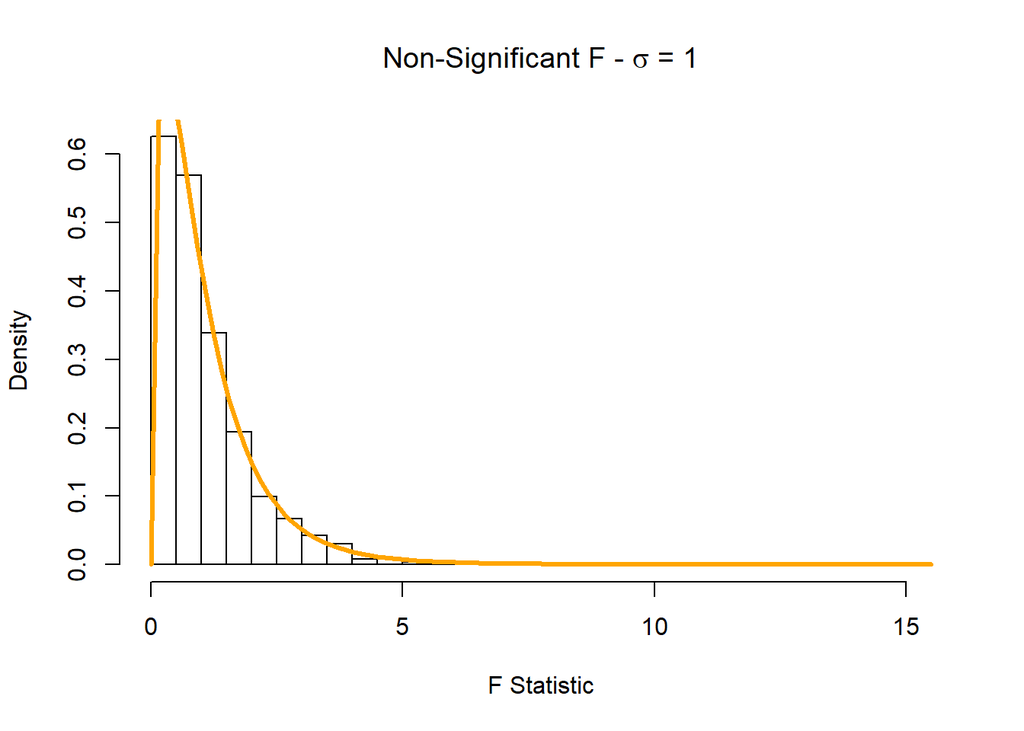

```r
#par(mfrow=c(1,3))
hist(sim1_data$non_f, prob = TRUE, breaks = 50,
     main = expression(paste("Non-Significant F - ", sigma, " = 1")),
     xlab = "F Statistic")
x = sim1_data$non_f
curve(df(x, df1 = p - 1, df2 = n - p), col = "Orange", add = TRUE, lwd = 3)
```

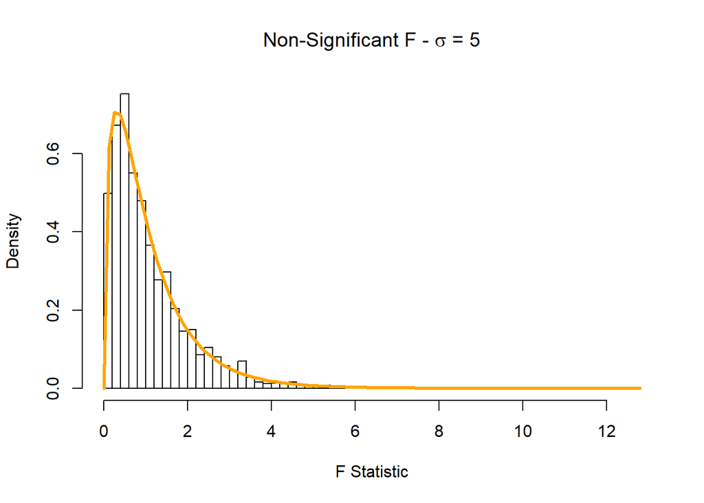

```r
hist(sim2_data$non_f, prob = TRUE, breaks = 50,
     main = expression(paste("Non-Significant F - ", sigma, " = 5")),
     xlab = "F Statistic")
x = sim2_data$non_f
curve(df(x, df1 = p - 1, df2 = n - p), col = "Orange", add = TRUE, lwd = 3)
```

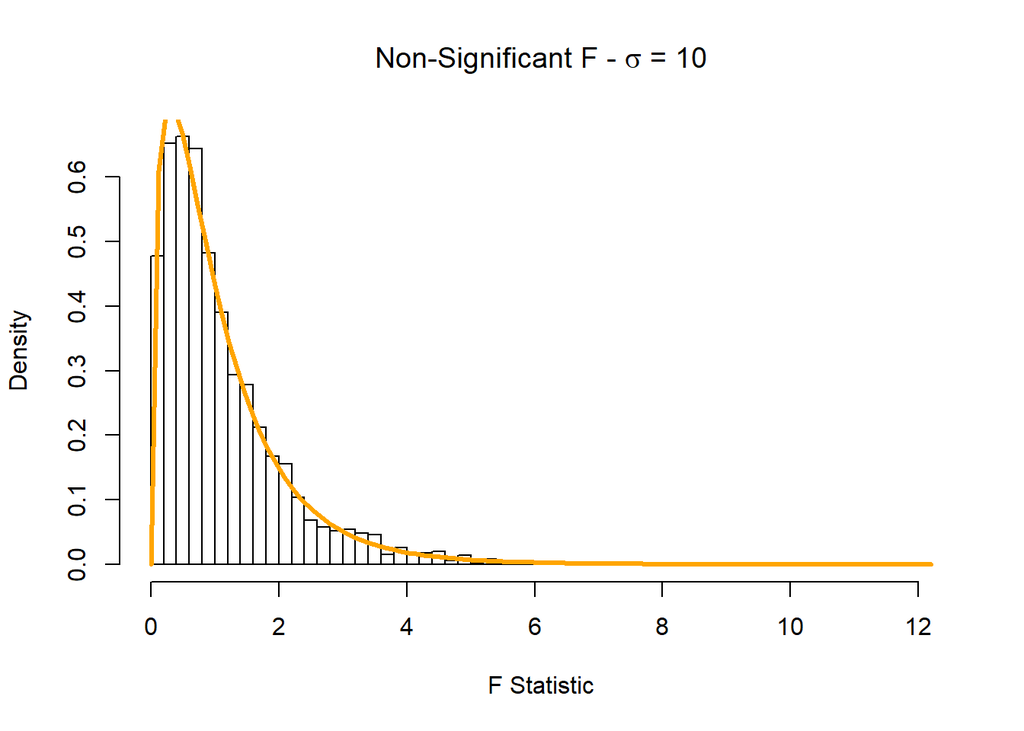

```r
hist(sim3_data$non_f, prob = TRUE, breaks = 50,
     main = expression(paste("Non-Significant F - ", sigma, " = 10")),
     xlab = "F Statistic")
x = sim3_data$non_f
curve(df(x, df1 = p - 1, df2 = n - p), col = "Orange", add = TRUE, lwd = 3)
```

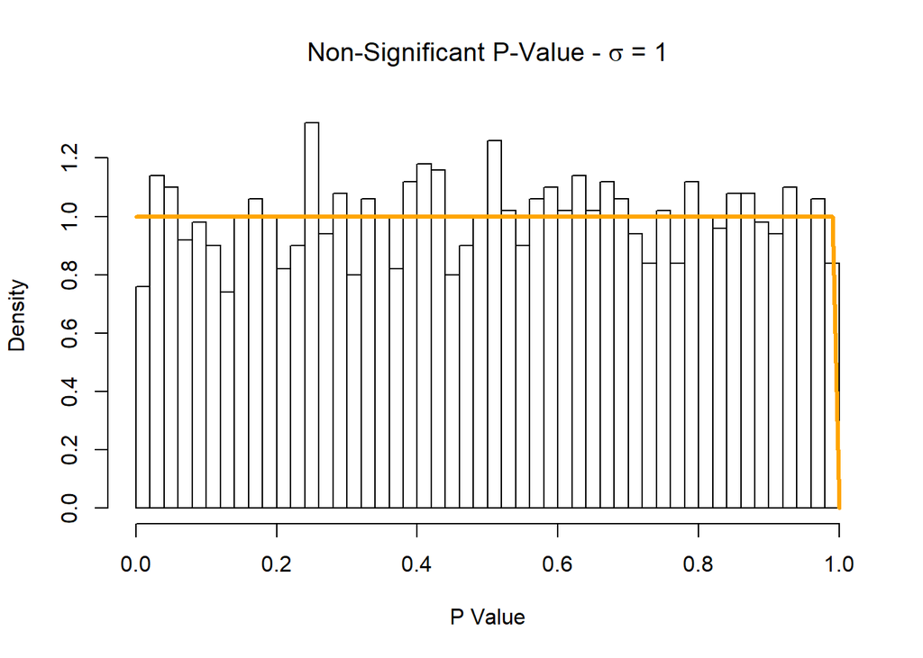

```r
#par(mfrow=c(3,1))
hist(sim1_data$non_p, prob = TRUE, breaks = 40,
     main = expression(paste("Non-Significant P-Value - ", sigma, " = 1")),
     xlab = "P Value")
x = sim1_data$non_p
curve(dunif(x), col="orange", add=TRUE, lwd=3)
```

[figure not shown]

```r
hist(sim1_data$non_p, prob = TRUE, breaks = 40,
     main = expression(paste("Non-Significant P-Value - ", sigma, " = 5")),
     xlab = "P Value")
x = sim1_data$non_p
curve(dunif(x), col="orange", add=TRUE, lwd=3)
```

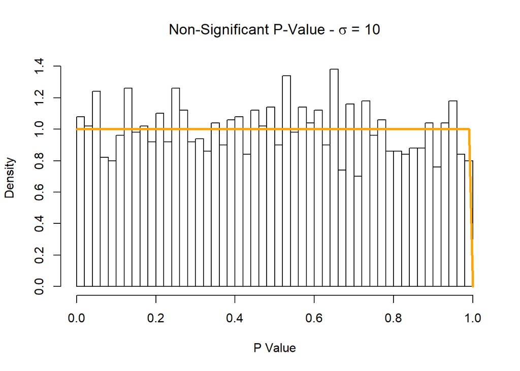

```r
hist(sim3_data$non_p, prob = TRUE, breaks = 40,
     main = expression(paste("Non-Significant P-Value - ", sigma, " = 10")),
     xlab = "P Value")
x = sim3_data$non_p
curve(dunif(x), col="orange", add=TRUE, lwd=3)
```

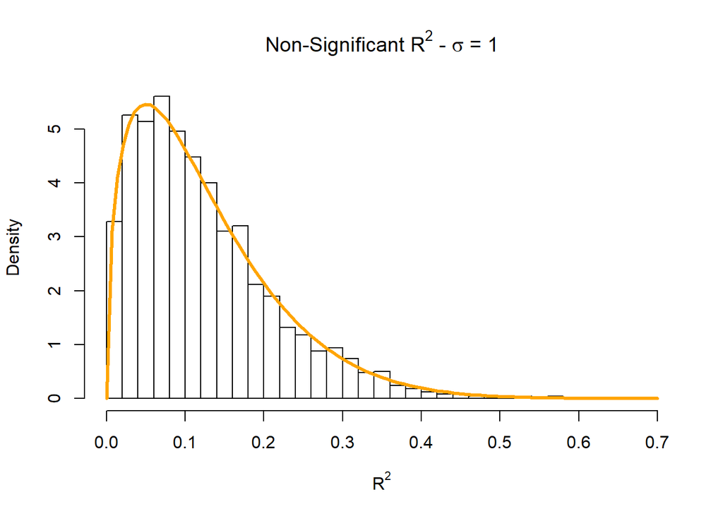

```r
#par(mfrow=c(1,3))
hist(sim1_data$non_r, prob = TRUE, breaks = 40,
     main = expression(paste("Non-Significant ", R^2, " - ", sigma, " = 1")),
     xlab = expression(R^2))
x = sim1_data$non_r
curve(dbeta(x, (p-1)/2, (n-p)/2), col="orange", add=TRUE, lwd=3)
```

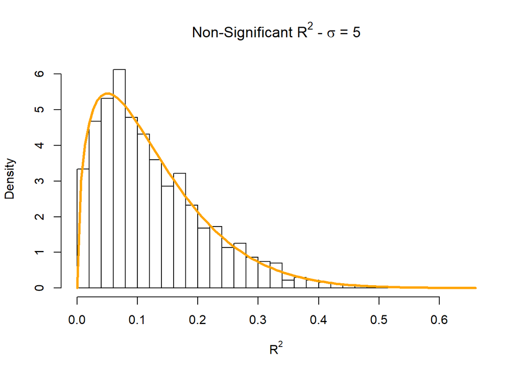

```r
hist(sim2_data$non_r, prob = TRUE, breaks = 40,
     main = expression(paste("Non-Significant ", R^2, " - ", sigma, " = 5")),
     xlab = expression(R^2))
x = sim2_data$non_r
curve(dbeta(x, (p-1)/2, (n-p)/2), col="orange", add=TRUE, lwd=3)
```

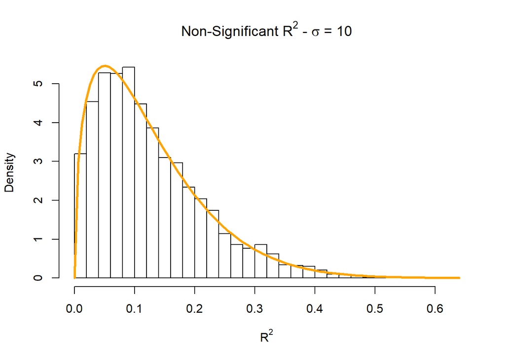

```r
hist(sim3_data$non_r, prob = TRUE, breaks = 40,
     main = expression(paste("Non-Significant ", R^2, " - ", sigma, " = 10")),
     xlab = expression(R^2))
x = sim3_data$non_r
curve(dbeta(x, (p-1)/2, (n-p)/2), col="orange", add=TRUE, lwd=3)
```

## Simulation Study 2: Using RMSE for Selection?

### **Introduction**

In this Simulation Study we will be looking at RMSE, root mean sequared error, when considering multiple models and will use simulation to determine if our selected model is the actual **best** model. The model we have selected to model is

- $Y_i = \beta_0 + \beta_1 x_{i1} + \beta_2 x_{i2} + \beta_3 x_{i3} + \beta_4 x_{i4} + \beta_5 x_{i5} + \beta_6 x_{i6} + \epsilon_i$
  - $\beta_0 = 0$
  - $\beta_1 = 5$
  - $\beta_2 = -4$
  - $\beta_3 = 1.6$
  - $\beta_4 = -1.1$
  - $\beta_5 = 0.7$
  - $\beta_6 = 0.3$
  - $\epsilon_i \sim N(0, \sigma^2)$ where $\sigma \in (1, 2, 4)$

From this model we will fit the following models

- $y \sim x1$
- $y \sim x1 + x2$
- $y \sim x1 + x2 + x3$
- $y \sim x1 + x2 + x3 + x4$
- $y \sim x1 + x2 + x3 + x4 + x5$
- $y \sim x1 + x2 + x3 + x4 + x5 + x6$
- $y \sim x1 + x2 + x3 + x4 + x5 + x6 + x7$
- $y \sim x1 + x2 + x3 + x4 + x5 + x6 + x7 + x8$
- $y \sim x1 + x2 + x3 + x4 + x5 + x6 + x7 + x8 + x9$

### **Methods**

```r
birthday = 19890927
set.seed(birthday)
library(readr)
study_2_data = read_csv("study_2.csv")
n = nrow(study_2_data)
p = 3 + 1
x0 = rep(1, n)
x1 = study_2_data$x1
x2 = study_2_data$x2
x3 = study_2_data$x3
x4 = study_2_data$x4
x5 = study_2_data$x5
x6 = study_2_data$x6
sigma = c(1, 2, 4)

beta_0 = 0
beta_1 = 5
beta_2 = -4
beta_3 = 1.6
beta_4 = -1.1
beta_5 = 0.7
beta_6 = 0.3

simulations = 1000

calculate_rmse  = function(actual, predicted) {
  return(sqrt(mean((actual - predicted)^2)))
}
```

Run our first simulation and store in a dataframe for our results

```r
sim1_rmse_train = data.frame(model_1 = rep(0, simulations), model_2 = rep(0, simulations), model_3 = rep(0, simulations),
                             model_4 = rep(0, simulations), model_5 = rep(0, simulations), model_6 = rep(0, simulations),
                             model_7 = rep(0, simulations), model_8 = rep(0, simulations), model_9 = rep(0, simulations))
sim1_rmse_test = data.frame(model_1 = rep(0, simulations), model_2 = rep(0, simulations), model_3 = rep(0, simulations),
                            model_4 = rep(0, simulations), model_5 = rep(0, simulations), model_6 = rep(0, simulations),
                            model_7 = rep(0, simulations), model_8 = rep(0, simulations), model_9 = rep(0, simulations))
for (iter in 1:simulations) {
  eps = rnorm(n, mean = 0, sd = sigma[1])
  study_2_data$y = beta_0 + beta_1 * x1 +  beta_2 * x2 + beta_3 * x3 + beta_4 * x4 + beta_5 * x5 + beta_6 * x6 + eps

  train_index = sample(n / 2)
  train_data = study_2_data[train_index,]
  test_data = study_2_data[-train_index,]

  model_1 = lm(y ~ x1, data = train_data)
  model_2 = lm(y ~ x1 + x2, data = train_data)
  model_3 = lm(y ~ x1 + x2 + x3, data = train_data)
  model_4 = lm(y ~ x1 + x2 + x3 + x4, data = train_data)
  model_5 = lm(y ~ x1 + x2 + x3 + x4 + x5, data = train_data)
  model_6 = lm(y ~ x1 + x2 + x3 + x4 + x5 + x6, data = train_data)
  model_7 = lm(y ~ x1 + x2 + x3 + x4 + x5 + x6 + x7, data = train_data)
  model_8 = lm(y ~ x1 + x2 + x3 + x4 + x5 + x6 + x7 + x8, data = train_data)
  model_9 = lm(y ~ x1 + x2 + x3 + x4 + x5 + x6 + x7 + x8 + x9, data = train_data)

  sim1_rmse_train$model_1[iter] = calculate_rmse(train_data$y, predict(model_1, train_data))
  sim1_rmse_train$model_2[iter] = calculate_rmse(train_data$y, predict(model_2, train_data))
  sim1_rmse_train$model_3[iter] = calculate_rmse(train_data$y, predict(model_3, train_data))
  sim1_rmse_train$model_4[iter] = calculate_rmse(train_data$y, predict(model_4, train_data))
  sim1_rmse_train$model_5[iter] = calculate_rmse(train_data$y, predict(model_5, train_data))
  sim1_rmse_train$model_6[iter] = calculate_rmse(train_data$y, predict(model_6, train_data))
  sim1_rmse_train$model_7[iter] = calculate_rmse(train_data$y, predict(model_7, train_data))
  sim1_rmse_train$model_8[iter] = calculate_rmse(train_data$y, predict(model_8, train_data))
  sim1_rmse_train$model_9[iter] = calculate_rmse(train_data$y, predict(model_9, train_data))

  sim1_rmse_test$model_1[iter] = calculate_rmse(test_data$y, predict(model_1, test_data))
  sim1_rmse_test$model_2[iter] = calculate_rmse(test_data$y, predict(model_2, test_data))
  sim1_rmse_test$model_3[iter] = calculate_rmse(test_data$y, predict(model_3, test_data))
  sim1_rmse_test$model_4[iter] = calculate_rmse(test_data$y, predict(model_4, test_data))
  sim1_rmse_test$model_5[iter] = calculate_rmse(test_data$y, predict(model_5, test_data))
  sim1_rmse_test$model_6[iter] = calculate_rmse(test_data$y, predict(model_6, test_data))
  sim1_rmse_test$model_7[iter] = calculate_rmse(test_data$y, predict(model_7, test_data))
  sim1_rmse_test$model_8[iter] = calculate_rmse(test_data$y, predict(model_8, test_data))
  sim1_rmse_test$model_9[iter] = calculate_rmse(test_data$y, predict(model_9, test_data))
}
```

Run our second simulation and store in a dataframe for our results

```r
sim2_rmse_train = data.frame(model_1 = rep(0, simulations), model_2 = rep(0, simulations), model_3 = rep(0, simulations),
                             model_4 = rep(0, simulations), model_5 = rep(0, simulations), model_6 = rep(0, simulations),
                             model_7 = rep(0, simulations), model_8 = rep(0, simulations), model_9 = rep(0, simulations))

sim2_rmse_test = data.frame(model_1 = rep(0, simulations), model_2 = rep(0, simulations), model_3 = rep(0, simulations),
                            model_4 = rep(0, simulations), model_5 = rep(0, simulations), model_6 = rep(0, simulations),
                            model_7 = rep(0, simulations), model_8 = rep(0, simulations), model_9 = rep(0, simulations))

for (iter in 1:simulations) {
  eps = rnorm(n, mean = 0, sd = sigma[2])
  study_2_data$y = beta_0 + beta_1 * x1 +  beta_2 * x2 + beta_3 * x3 + beta_4 * x4 + beta_5 * x5 + beta_6 * x6 + eps

  train_index = sample(n / 2)
  train_data = study_2_data[train_index,]
  test_data = study_2_data[-train_index,]

  model_1 = lm(y ~ x1, data = train_data)
  model_2 = lm(y ~ x1 + x2, data = train_data)
  model_3 = lm(y ~ x1 + x2 + x3, data = train_data)
  model_4 = lm(y ~ x1 + x2 + x3 + x4, data = train_data)
  model_5 = lm(y ~ x1 + x2 + x3 + x4 + x5, data = train_data)
  model_6 = lm(y ~ x1 + x2 + x3 + x4 + x5 + x6, data = train_data)
  model_7 = lm(y ~ x1 + x2 + x3 + x4 + x5 + x6 + x7, data = train_data)
  model_8 = lm(y ~ x1 + x2 + x3 + x4 + x5 + x6 + x7 + x8, data = train_data)
  model_9 = lm(y ~ x1 + x2 + x3 + x4 + x5 + x6 + x7 + x8 + x9, data = train_data)


  sim2_rmse_train$model_1[iter] = calculate_rmse(train_data$y, predict(model_1, train_data))
  sim2_rmse_train$model_2[iter] = calculate_rmse(train_data$y, predict(model_2, train_data))
  sim2_rmse_train$model_3[iter] = calculate_rmse(train_data$y, predict(model_3, train_data))
  sim2_rmse_train$model_4[iter] = calculate_rmse(train_data$y, predict(model_4, train_data))
  sim2_rmse_train$model_5[iter] = calculate_rmse(train_data$y, predict(model_5, train_data))
  sim2_rmse_train$model_6[iter] = calculate_rmse(train_data$y, predict(model_6, train_data))
  sim2_rmse_train$model_7[iter] = calculate_rmse(train_data$y, predict(model_7, train_data))
  sim2_rmse_train$model_8[iter] = calculate_rmse(train_data$y, predict(model_8, train_data))
  sim2_rmse_train$model_9[iter] = calculate_rmse(train_data$y, predict(model_9, train_data))

  sim2_rmse_test$model_1[iter] = calculate_rmse(test_data$y, predict(model_1, test_data))
  sim2_rmse_test$model_2[iter] = calculate_rmse(test_data$y, predict(model_2, test_data))
  sim2_rmse_test$model_3[iter] = calculate_rmse(test_data$y, predict(model_3, test_data))
  sim2_rmse_test$model_4[iter] = calculate_rmse(test_data$y, predict(model_4, test_data))
  sim2_rmse_test$model_5[iter] = calculate_rmse(test_data$y, predict(model_5, test_data))
  sim2_rmse_test$model_6[iter] = calculate_rmse(test_data$y, predict(model_6, test_data))
  sim2_rmse_test$model_7[iter] = calculate_rmse(test_data$y, predict(model_7, test_data))
  sim2_rmse_test$model_8[iter] = calculate_rmse(test_data$y, predict(model_8, test_data))
  sim2_rmse_test$model_9[iter] = calculate_rmse(test_data$y, predict(model_9, test_data))
}
```

Run our third simulation and store in a dataframe for our results

```r
sim3_rmse_train = data.frame(model_1 = rep(0, simulations), model_2 = rep(0, simulations), model_3 = rep(0, simulations),
                             model_4 = rep(0, simulations), model_5 = rep(0, simulations), model_6 = rep(0, simulations),
                             model_7 = rep(0, simulations), model_8 = rep(0, simulations), model_9 = rep(0, simulations))

sim3_rmse_test = data.frame(model_1 = rep(0, simulations), model_2 = rep(0, simulations), model_3 = rep(0, simulations),
                            model_4 = rep(0, simulations), model_5 = rep(0, simulations), model_6 = rep(0, simulations),
                            model_7 = rep(0, simulations), model_8 = rep(0, simulations), model_9 = rep(0, simulations))

for (iter in 1:simulations) {
  eps = rnorm(n, mean = 0, sd = sigma[3])
  study_2_data$y = beta_0 + beta_1 * x1 +  beta_2 * x2 + beta_3 * x3 + beta_4 * x4 + beta_5 * x5 + beta_6 * x6 + eps

  train_index = sample(n / 2)
  train_data = study_2_data[train_index,]
  test_data = study_2_data[-train_index,]

  model_1 = lm(y ~ x1, data = train_data)
  model_2 = lm(y ~ x1 + x2, data = train_data)
  model_3 = lm(y ~ x1 + x2 + x3, data = train_data)
  model_4 = lm(y ~ x1 + x2 + x3 + x4, data = train_data)
  model_5 = lm(y ~ x1 + x2 + x3 + x4 + x5, data = train_data)
  model_6 = lm(y ~ x1 + x2 + x3 + x4 + x5 + x6, data = train_data)
  model_7 = lm(y ~ x1 + x2 + x3 + x4 + x5 + x6 + x7, data = train_data)
  model_8 = lm(y ~ x1 + x2 + x3 + x4 + x5 + x6 + x7 + x8, data = train_data)
  model_9 = lm(y ~ x1 + x2 + x3 + x4 + x5 + x6 + x7 + x8 + x9, data = train_data)



  sim3_rmse_train$model_1[iter] = calculate_rmse(train_data$y, predict(model_1, train_data))
  sim3_rmse_train$model_2[iter] = calculate_rmse(train_data$y, predict(model_2, train_data))
  sim3_rmse_train$model_3[iter] = calculate_rmse(train_data$y, predict(model_3, train_data))
  sim3_rmse_train$model_4[iter] = calculate_rmse(train_data$y, predict(model_4, train_data))
  sim3_rmse_train$model_5[iter] = calculate_rmse(train_data$y, predict(model_5, train_data))
  sim3_rmse_train$model_6[iter] = calculate_rmse(train_data$y, predict(model_6, train_data))
  sim3_rmse_train$model_7[iter] = calculate_rmse(train_data$y, predict(model_7, train_data))
  sim3_rmse_train$model_8[iter] = calculate_rmse(train_data$y, predict(model_8, train_data))
  sim3_rmse_train$model_9[iter] = calculate_rmse(train_data$y, predict(model_9, train_data))

  sim3_rmse_test$model_1[iter] = calculate_rmse(test_data$y, predict(model_1, test_data))
  sim3_rmse_test$model_2[iter] = calculate_rmse(test_data$y, predict(model_2, test_data))
  sim3_rmse_test$model_3[iter] = calculate_rmse(test_data$y, predict(model_3, test_data))
  sim3_rmse_test$model_4[iter] = calculate_rmse(test_data$y, predict(model_4, test_data))
  sim3_rmse_test$model_5[iter] = calculate_rmse(test_data$y, predict(model_5, test_data))
  sim3_rmse_test$model_6[iter] = calculate_rmse(test_data$y, predict(model_6, test_data))
  sim3_rmse_test$model_7[iter] = calculate_rmse(test_data$y, predict(model_7, test_data))
  sim3_rmse_test$model_8[iter] = calculate_rmse(test_data$y, predict(model_8, test_data))
  sim3_rmse_test$model_9[iter] = calculate_rmse(test_data$y, predict(model_9, test_data))
}
```

### **Results**

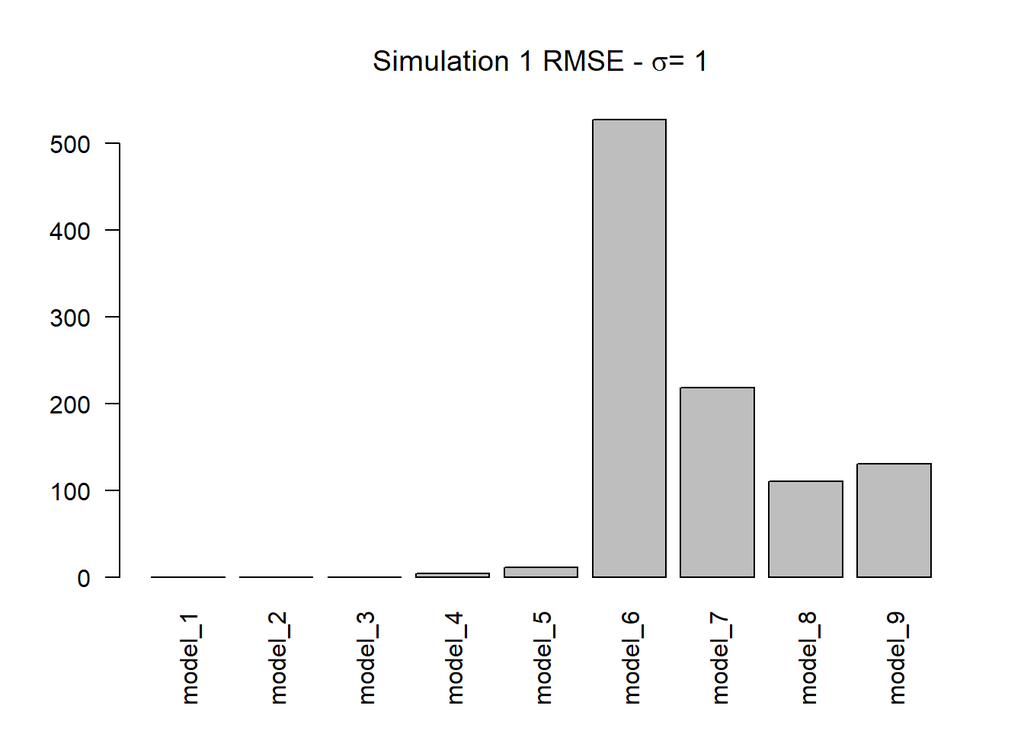

```r
barplot(table(factor(colnames(sim1_rmse_test)[apply(sim1_rmse_test, 1, function(x) which.min(x))], levels = colnames(sim1_rmse_test))),
        main = expression(paste("Simulation 1 RMSE - ", sigma, "= 1")), las = 2)
```

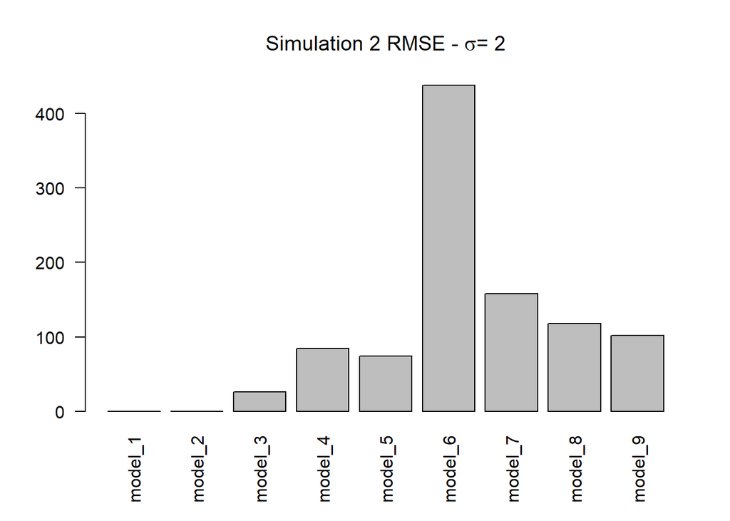

```r
barplot(table(factor(colnames(sim2_rmse_test)[apply(sim2_rmse_test, 1, function(x) which.min(x))], levels = colnames(sim2_rmse_test))),
        main = expression(paste("Simulation 2 RMSE - ", sigma, "= 2")), las = 2)
```

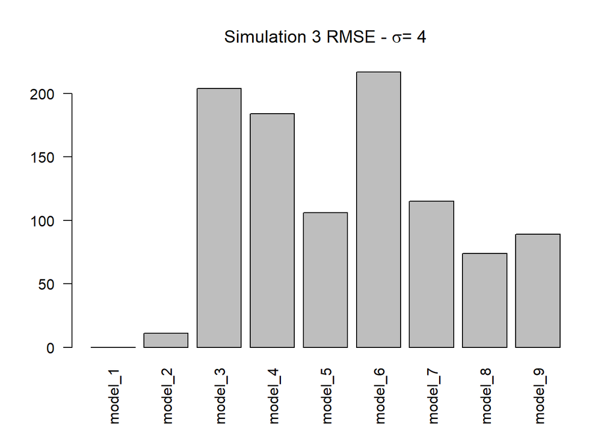

```r
barplot(table(factor(colnames(sim3_rmse_test)[apply(sim3_rmse_test, 1, function(x) which.min(x))], levels = colnames(sim3_rmse_test))),
        main = expression(paste("Simulation 3 RMSE - ", sigma, "= 4")), las = 2)
```

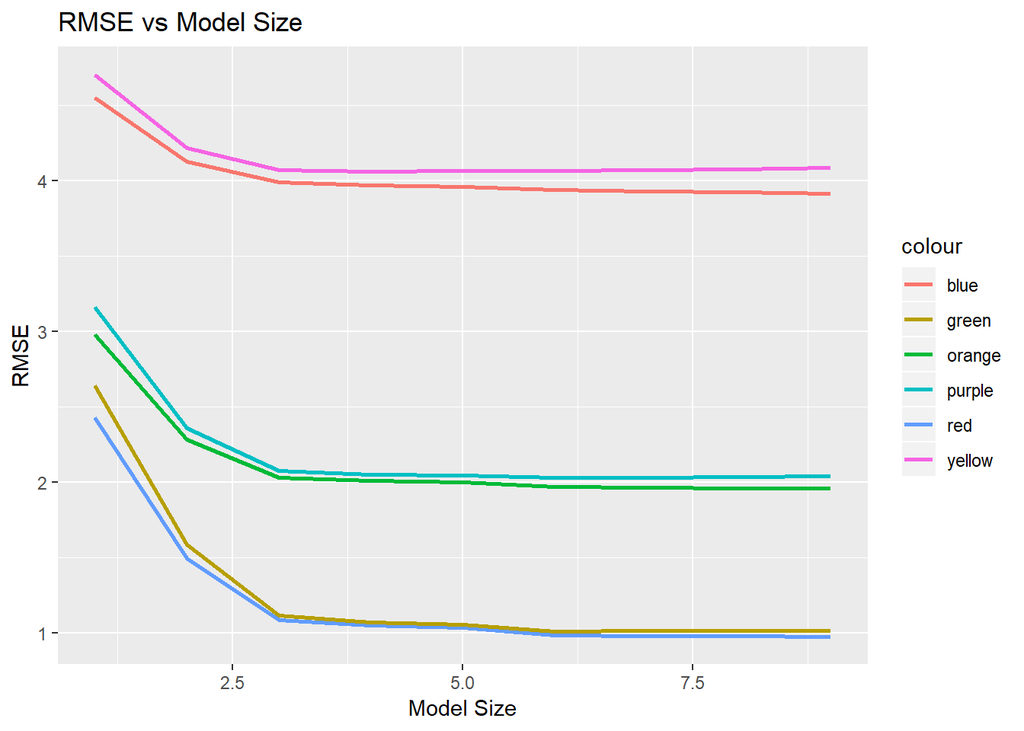

```r
library(ggplot2)
x_vals = seq(1, 9, 1)
sigma_1_train = apply(sim1_rmse_train, 2, mean)
sigma_2_train = apply(sim2_rmse_train, 2, mean)
sigma_3_train = apply(sim3_rmse_train, 2, mean)
sigma_1_test = apply(sim1_rmse_test, 2, mean)
sigma_2_test = apply(sim2_rmse_test, 2, mean)
sigma_3_test = apply(sim3_rmse_test, 2, mean)
train_test_data = data.frame(x_vals, sigma_1_train, sigma_2_train, sigma_3_train, sigma_1_test, sigma_2_test, sigma_3_test)
colnames(train_test_data) = c("x_vals", "sigma_1_train", "sigma_2_train", "sigma_3_train", "sigma_1_test", "sigma_2_test", "sigma_3_test")
ggplot(data=train_test_data, aes(x = x_vals)) +
  geom_line(aes(x = x_vals, y = sigma_1_train, color = "red"), size=1) +
  geom_line(aes(x = x_vals, y = sigma_2_train, color = "orange"), size=1) +
  geom_line(aes(x = x_vals, y = sigma_3_train, color = "blue"), size=1) +
  geom_line(aes(x = x_vals, y = sigma_1_test, color = "green"), size=1) +
  geom_line(aes(x = x_vals, y = sigma_2_test, color = "purple"), size=1) +
  geom_line(aes(x = x_vals, y = sigma_3_test, color = "yellow"), size=1) +
  xlab("Model Size") +
  ylab("RMSE") +
  ggtitle("RMSE vs Model Size")
```

## Simulation Study 3: Power

### **Introduction**

In this Simulation Study we will be looking at **power** on a simple linear regression test of the following

$H_0: \beta_1 = 0\: vs\: H_1: \ne 0$

We define **power** as the probability of reject the null hypothesis when the null is not true or can be written as $P[Reject \: H_0| H_1 \: True]$. In order to test this with simulation we will simulate

$$Y_i = \beta_0 + \beta_1 x_{1i}+ \epsilon_i$$

- $\beta_0 = 0$
- $\beta_1 \in (-2, -1.9, ..., 1.9, 2)$
- $\epsilon_i \sim N(0, \sigma^2)$ where $\sigma \in (1, 2, 4)$

For this we will also use a variable sample size of $n \in (10, 20, 30)$, but for our test we will hold $\alpha = 0.05$ for testing our $p-value$ we generate from simulating $1,000$ times. At the end we will look at how **power** changes depending on $\beta_1$, $n$, and $\sigma$.

### **Methods**

Setup the variables for our power simulation.

```r
birthday = 19890927
set.seed(birthday)
beta_0 = 0
beta_1_list = seq(-2, 2, .1)
sigmas = c(1, 2, 4)
samples = c(10, 20, 30)
alpha = 0.05
simulations = 1000
number_iterations = length(sigmas) * length(samples) * length(beta_1_list)
```

Run our simulation for power.

```r
power_data = data.frame(sigma = rep(0, number_iterations), n = rep(0, number_iterations),
                        beta_1 = rep(0, number_iterations), power = rep(0, number_iterations))
i = 1
for (sigma in sigmas) {
  for (n in samples) {
    x_values = seq(0, 5, length = n)
    for (beta_1 in beta_1_list) {
      rejected = 0
      for (iter in 1:simulations) {
        eps = rnorm(n, 0, sigma)
        y = beta_0 + beta_1 * x_values + eps
        model = lm(y ~ x_values)
        beta_1_p = summary(model)$coefficients[2, 4]
        if (beta_1_p < alpha) {
          rejected = rejected + 1
        }
      }
      power = rejected / simulations
      power_data$sigma[i] = sigma
      power_data$n[i] = n
      power_data$beta_1[i] = beta_1
      power_data$power[i] = power
      i = i + 1
    }
  }
}
```

### **Results**

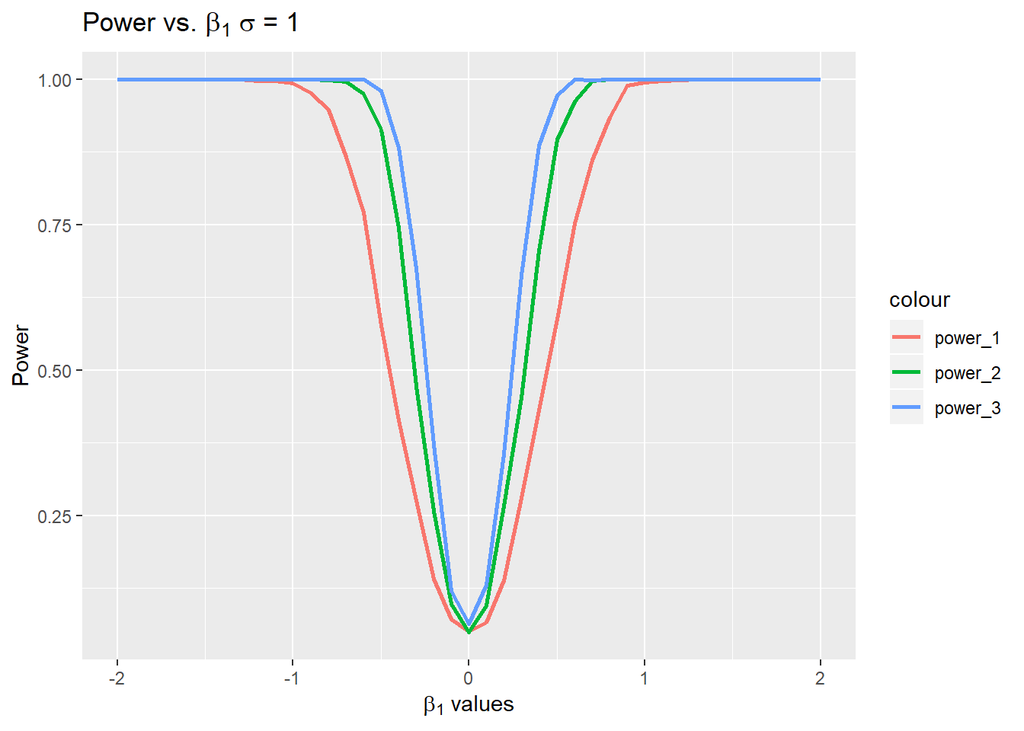

```r
beta_1 = power_data[which((power_data$n == 10) & (power_data$sigma == 1)), c("beta_1")]
power1 = power_data[which((power_data$n == 10) & (power_data$sigma == 1)), c("power")]
power2 = power_data[which((power_data$n == 20) & (power_data$sigma == 1)), c("power")]
power3 = power_data[which((power_data$n == 30) & (power_data$sigma == 1)), c("power")]

power_graph_data = data.frame(beta_1 = beta_1, power_1 = power1, power_2 = power2, power_3 = power3)

ggplot(data=power_graph_data, aes(x = beta_1)) + geom_line(aes(x = beta_1, y = power_1, color = "power_1"), size=1) +   geom_line(aes(x = beta_1, y = power_2, color = "power_2"), size=1) +
  geom_line(aes(x = beta_1, y = power_3, color = "power_3"), size=1) +
  xlab(expression(paste("", beta[1], " values"))) +
  ylab("Power") +
  ggtitle(expression(paste("Power vs. ", beta[1], " ", sigma, " = 1")))
```

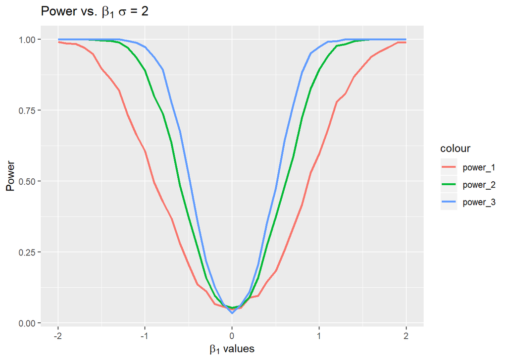

```r
power1 = power_data[which((power_data$n == 10) & (power_data$sigma == 2)), c("power")]
power2 = power_data[which((power_data$n == 20) & (power_data$sigma == 2)), c("power")]
power3 = power_data[which((power_data$n == 30) & (power_data$sigma == 2)), c("power")]

power_graph_data = data.frame(beta_1 = beta_1, power_1 = power1, power_2 = power2, power_3 = power3)

ggplot(data=power_graph_data, aes(x = beta_1)) + geom_line(aes(x = beta_1, y = power_1, color = "power_1"), size=1) +   geom_line(aes(x = beta_1, y = power_2, color = "power_2"), size=1) +
  geom_line(aes(x = beta_1, y = power_3, color = "power_3"), size=1) +
  xlab(expression(paste(beta[1], " values"))) +
  ylab("Power") +
  ggtitle(expression(paste("Power vs. ", beta[1], " ", sigma, " = 2")))
```

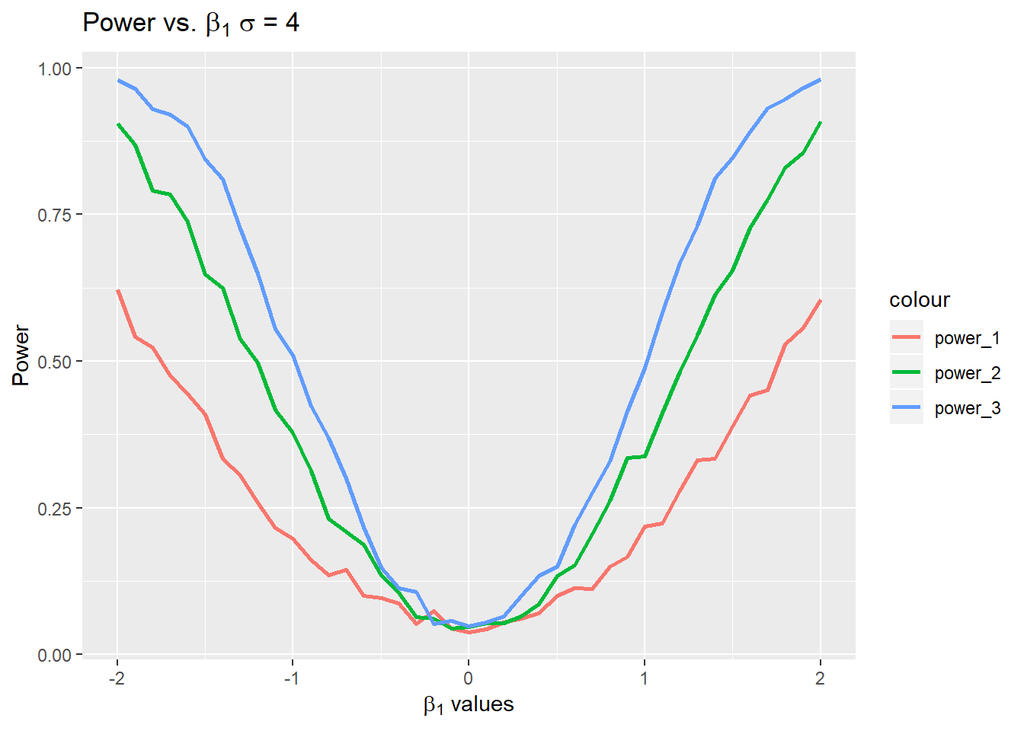

```r
power1 = power_data[which((power_data$n == 10) & (power_data$sigma == 4)), c("power")]
power2 = power_data[which((power_data$n == 20) & (power_data$sigma == 4)), c("power")]
power3 = power_data[which((power_data$n == 30) & (power_data$sigma == 4)), c("power")]

power_graph_data = data.frame(beta_1 = beta_1, power_1 = power1, power_2 = power2, power_3 = power3)

ggplot(data=power_graph_data, aes(x = beta_1)) + geom_line(aes(x = beta_1, y = power_1, color = "power_1"), size=1) +   geom_line(aes(x = beta_1, y = power_2, color = "power_2"), size=1) +
  geom_line(aes(x = beta_1, y = power_3, color = "power_3"), size=1) +
  xlab(expression(paste(beta[1], " values"))) +
  ylab("Power") +
  ggtitle(expression(paste("Power vs. ", beta[1], " ", sigma, " = 4")))
```

```r
mean_sigmas = rep(0, length(sigmas))
i = 1
for (sigma in sigmas) {
  mean_sigmas[i] = mean(power_data$power[power_data$sigma == sigma])
  i = i + 1
}
mean_beta_1s = rep(0, length(beta_1_list))
i = 1
for (beta_1 in beta_1_list) {
  mean_beta_1s[i] = mean(power_data$power[power_data$beta_1 == beta_1])
  i = i + 1
}
mean_n = rep(0, length(samples))
i = 1
for (sample in samples) {
  mean_n[i] = mean(power_data$power[power_data$n == sample])
  i = i + 1
}
```

### **Discussion**

* **How do n, $\beta_1$, and $\sigma$ affect power? Consider additional plots to demonstrate these effects.**  
For each of these values we will refer to the graphs to prove that they have an impact upon power.  
For n, it is easy to see that as sample size increases we are sampling the Power increases much quicker which implies that there is a relationship between n and Power. This makes sense if we consider that as we increase our sample size we are decreasing the affect of random outliers that are generated and thus increasing our faith that our data is more resilient to these outliers.  
For $\beta_1$, it is easy to see that as we increased our $\beta_1$ value that around 1 we reached a limit of $1$ due to probabilities being unable to reach values greater than $1$. Furthermore, as we moved away from our null hypothesis that $\beta_1 = 0$ we are able to see that power started gaining thus giving us more faith that by rejecting our null hypothesis given that our alternative hypothesis is correct.  
For $\sigma$, it is easy to see that as we increased $\sigma$ we are impacting power as our graphs start to flatten out as $\sigma$ increases. This is expected as we are imparting more variance into our data generation which means we are decreasing our faith that we are properly rejecting our null hypothesis.

- **Are 1000 simulations sufficient?**  
  I believe 1000 simulations is sufficient because as a test I increased it to 2000 to see if there was a difference. What I observed was that there is not a noticable difference other than the graphs looking smoother. This is to be expected though as we have trained 369,000 models for this study which is a rather large sample of models so if we continue this to 738,000 models we would not expect for our values to differ, but for our graphs to look better as we are generating values for each $\beta_1$ to be closer to the expected.